# Importando Bibliotecas Necessárias

```python
import pandas as pd
import numpy as np
import seaborn as sns
import matplotlib
import plotly.express as px

import matplotlib.pyplot as plt
from scipy.stats import skew
from scipy.stats.stats import pearsonr

from sklearn.linear_model import Ridge, RidgeCV, ElasticNet, Lasso, LassoCV, LassoLarsCV, LinearRegression
from sklearn.model_selection import cross_val_score
from sklearn.tree import DecisionTreeRegressor
```

# Lendo os dados

```python
eleicoes_2006_a_2010 = pd.read_csv("/content/drive/MyDrive/Mestrado/CADEIRAS/Aprendizagem de Maquina/regressao multipla/eleicoes_2006_a_2010.csv")
eleicoes_2014 = pd.read_csv("/content/drive/MyDrive/Mestrado/CADEIRAS/Aprendizagem de Maquina/regressao multipla/eleicoes_2014.csv")

eleicoes_2006_a_2010.info()
```

```
<class 'pandas.core.frame.DataFrame'>
RangeIndex: 7330 entries, 0 to 7329
Data columns (total 23 columns):
 #   Column                                 Non-Null Count  Dtype
---  ------                                 --------------  -----
 0   ano                                    7330 non-null   int64
 1   sequencial_candidato                   7330 non-null   int64
 2   nome                                   7330 non-null   object
 3   uf                                     7330 non-null   object
 4   partido                                7330 non-null   object
 5   quantidade_doacoes                     7330 non-null   int64
 6   quantidade_doadores                    7330 non-null   int64
 7   total_receita                          7169 non-null   float64
 8   media_receita                          7169 non-null   float64
 9   recursos_de_outros_candidatos/comites  4940 non-null   float64
 10  recursos_de_pessoas_fisicas            4647 non-null   float64
 11  recursos_de_pessoas_juridicas          3354 non-null   float64
 12  recursos_proprios                      4942 non-null   float64
 13  quantidade_despesas                    7330 non-null   int64
 14  quantidade_fornecedores                7330 non-null   int64
 15  total_despesa                          7330 non-null   float64
 16  media_despesa                          7330 non-null   float64
 17  cargo                                  7330 non-null   object
 18  sexo                                   7330 non-null   object
 19  grau                                   7330 non-null   object
 20  estado_civil                           7330 non-null   object
 21  ocupacao                               7330 non-null   object
 22  votos                                  7330 non-null   int64
dtypes: float64(8), int64(7), object(8)
memory usage: 1.3+ MB
```

```python
eleicoes_2014.info()
```

```
<class 'pandas.core.frame.DataFrame'>
RangeIndex: 4936 entries, 0 to 4935
Data columns (total 23 columns):
 #   Column                                 Non-Null Count  Dtype
---  ------                                 --------------  -----
 0   ano                                    4936 non-null   int64
 1   sq_candidato                           4936 non-null   int64
 2   nome_candidato                         4936 non-null   object
 3   sigla_uf                               4936 non-null   object
 4   sigla_partido                          4936 non-null   object
 5   qtd_doacoes                            4936 non-null   int64
 6   qtd_doadores                           4936 non-null   int64
 7   total_receita                          4936 non-null   float64
 8   media_receita                          4936 non-null   float64
 9   recursos de outros candidatos/comitês  3191 non-null   float64
 10  recursos de pessoas físicas            3727 non-null   float64
 11  recursos de pessoas jurídicas          1714 non-null   float64
 12  recursos próprios                      2860 non-null   float64
 13  qtd_despesas                           4936 non-null   int64
 14  qtd_fornecedores                       4936 non-null   int64
 15  total_despesa                          4936 non-null   float64
 16  media_despesa                          4936 non-null   float64
 17  descricao_cargo                        4936 non-null   object
 18  sexo                                   4936 non-null   object
 19  grau_instrucao                         4936 non-null   object
 20  estado_civil                           4936 non-null   object
 21  descricao_ocupacao                     4936 non-null   object
 22  votos                                  4936 non-null   int64
dtypes: float64(8), int64(7), object(8)
memory usage: 887.1+ KB
```

### As colunas tem nomes diferentes, precisamos corrigir.

```python
eleicoes_2014 = eleicoes_2014.rename(columns={"sq_candidato": "sequencial_candidato",
                                              "nome_candidato": "nome",
                                              "sigla_uf": "uf",
                                              "sigla_partido": "partido",
                                              "qtd_doacoes": "quantidade_doacoes",
                                              "qtd_doadores": "quantidade_doadores",
                                              "recursos de outros candidatos/comitês": "recursos_de_outros_candidatos/comites",
                                              "recursos de pessoas físicas": "recursos_de_pessoas_fisicas",
                                              "recursos de pessoas jurídicas": "recursos_de_pessoas_juridicas",
                                              "recursos próprios": "recursos_proprios",
                                              "qtd_despesas": "quantidade_despesas",
                                              "qtd_fornecedores": "quantidade_fornecedores",
                                              "descricao_cargo": "cargo",
                                              "grau_instrucao": "grau",
                                              "descricao_ocupacao": "ocupacao"})
```

```python
data = pd.concat([eleicoes_2006_a_2010, eleicoes_2014])
data.head()
```

|  | ano | sequencial_candidato | nome | uf | partido | quantidade_doacoes | quantidade_doadores | total_receita | media_receita | recursos_de_outros_candidatos/comites | ... | quantidade_despesas | quantidade_fornecedores | total_despesa | media_despesa | cargo | sexo | grau | estado_civil | ocupacao | votos |
| --- | --- | --- | --- | --- | --- | --- | --- | --- | --- | --- | --- | --- | --- | --- | --- | --- | --- | --- | --- | --- | --- |
| 0 | 2006 | 10001 | JOSÉ LUIZ NOGUEIRA DE SOUSA | AP | PT | 6 | 6 | 16600.00 | 2766.666667 | NaN | ... | 14 | 14 | 16583.60 | 1184.542857 | DEPUTADO FEDERAL | MASCULINO | ENSINO MÉDIO COMPLETO | CASADO(A) | VEREADOR | 8579 |
| 1 | 2006 | 10002 | LOIVA DE OLIVEIRA | RO | PT | 13 | 13 | 22826.00 | 1755.846154 | 6625.0 | ... | 24 | 23 | 20325.99 | 883.738696 | DEPUTADO FEDERAL | FEMININO | SUPERIOR COMPLETO | SOLTEIRO(A) | SERVIDOR PÚBLICO ESTADUAL | 2757 |
| 2 | 2006 | 10002 | MARIA DALVA DE SOUZA FIGUEIREDO | AP | PT | 17 | 16 | 148120.80 | 9257.550000 | 2250.0 | ... | 123 | 108 | 146011.70 | 1351.960185 | DEPUTADO FEDERAL | FEMININO | SUPERIOR COMPLETO | VIÚVO(A) | PEDAGOGO | 17428 |
| 3 | 2006 | 10002 | ROMALDO MILANI | MS | PRONA | 6 | 6 | 3001.12 | 500.186667 | NaN | ... | 8 | 8 | 3001.12 | 375.140000 | DEPUTADO FEDERAL | MASCULINO | ENSINO MÉDIO INCOMPLETO | CASADO(A) | MILITAR REFORMADO | 1193 |
| 4 | 2006 | 10003 | ANSELMO DE JESUS ABREU | RO | PT | 48 | 48 | NaN | NaN | NaN | ... | 133 | 120 | 116416.64 | 970.138667 | DEPUTADO FEDERAL | MASCULINO | ENSINO FUNDAMENTAL COMPLETO | CASADO(A) | DEPUTADO | 29401 |

5 rows × 23 columns

# Análise e Interpretação dos Dados

```python
data.info()
```

```
<class 'pandas.core.frame.DataFrame'>
Int64Index: 12266 entries, 0 to 4935
Data columns (total 23 columns):
 #   Column                                 Non-Null Count  Dtype
---  ------                                 --------------  -----
 0   ano                                    12266 non-null  int64
 1   sequencial_candidato                   12266 non-null  int64
 2   nome                                   12266 non-null  object
 3   uf                                     12266 non-null  object
 4   partido                                12266 non-null  object
 5   quantidade_doacoes                     12266 non-null  int64
 6   quantidade_doadores                    12266 non-null  int64
 7   total_receita                          12105 non-null  float64
 8   media_receita                          12105 non-null  float64
 9   recursos_de_outros_candidatos/comites  8131 non-null   float64
 10  recursos_de_pessoas_fisicas            8374 non-null   float64
 11  recursos_de_pessoas_juridicas          5068 non-null   float64
 12  recursos_proprios                      7802 non-null   float64
 13  quantidade_despesas                    12266 non-null  int64
 14  quantidade_fornecedores                12266 non-null  int64
 15  total_despesa                          12266 non-null  float64
 16  media_despesa                          12266 non-null  float64
 17  cargo                                  12266 non-null  object
 18  sexo                                   12266 non-null  object
 19  grau                                   12266 non-null  object
 20  estado_civil                           12266 non-null  object
 21  ocupacao                               12266 non-null  object
 22  votos                                  12266 non-null  int64
dtypes: float64(8), int64(7), object(8)
memory usage: 2.2+ MB
```

**Descrevendo as variáveis:** "ano": ano da candidatura. "sequencial_candidato": id do candidato.  
"nome": nome do candidato.  
"uf": estado do candidato. "partido": partido do candidato.  
"quantidade_doacoes": quantidade de doações recebidas.  
"quantidade_doadores": número de doadores diferentes.  
"total_receita": soma em reais das doações.  
"media_receita": média das doações.  
"recursos_de_outros_candidatos/comites": quantia em reais das doações provenientes de outros candidatos ou comite partidário.  
"recursos_de_pessoas_fisicas": quantia em reais das doações provenientes de outros CPFs.  
"recursos_de_pessoas_juridicas": quantia em reais das doações provenientes de outros CNPJ.  
"recursos_proprios": quantia em reais das doações provenientes do próprio candidato.  
"recursos_de_partido_politico": quantia em reais das doações provenientes do partido político do candidato.  
"votos": (integer) variável alvo. Se refere ao número de votos na campanha de 2006 e 2010.  
"quantidade_despesas": número de despesas.  
"quantidade_fornecedores": número de fornecedores/despesas diferentes.  
"total_despesa": soma em R$ das despesas de campanha.  
"media_despesa": média das despesas de campanha.  
"cargo": cargo do candidato.  
"Sexo": sexo do candidato.  
"grau": grau de instrução do candidato.  
"estado_civil": estado civil do candidato.  
"ocupacao": ocupação do candidato.

Ao todo tem-se 23 variáveis das quais, 10 são categóricas, sendo elas: 'ano', 'sequencial_candidato', 'nome', 'uf', 'partido', 'cargo', 'sexo', 'grau', 'estado_civil' e 'ocupacao'.  
**A variável alvo é: Voto.**

## Verificando dados faltantes

```python
def checkNA(dataframe):
  cols_with_na = []
  for col in dataframe.columns:
    print(col)
    bool_series = pd.isna(dataframe[col])
    if(bool_series.any()):
      cols_with_na.append(col)

  print("As colunas que possuem dados faltantes são: ", ", ".join(cols_with_na))

checkNA(data)
```

```
ano
sequencial_candidato
nome
uf
partido
quantidade_doacoes
quantidade_doadores
total_receita
media_receita
recursos_de_outros_candidatos/comites
recursos_de_pessoas_fisicas
recursos_de_pessoas_juridicas
recursos_proprios
quantidade_despesas
quantidade_fornecedores
total_despesa
media_despesa
cargo
sexo
grau
estado_civil
ocupacao
votos
As colunas que possuem dados faltantes são:  total_receita, media_receita, recursos_de_outros_candidatos/comites, recursos_de_pessoas_fisicas, recursos_de_pessoas_juridicas, recursos_proprios
```

## Verificando opções existentes nas variáveis categóricas

```python
col_categoricas = ['ano', 'sequencial_candidato', 'nome', 'uf', 'partido', 'cargo', 'sexo', 'grau', 'estado_civil', 'ocupacao']
data_categoricas = pd.DataFrame(data, columns=col_categoricas)

for col in data_categoricas:
  unique_vals = data_categoricas[col].unique()
  print("Coluna:", col)
  print("A coluna {0} possui {1} valor(es) distinto(s).".format(col,len(unique_vals)))
  print(unique_vals)
  print()
```

```
Coluna: ano
A coluna ano possui 3 valor(es) distinto(s).
[2006 2010 2014]

Coluna: sequencial_candidato
A coluna sequencial_candidato possui 9877 valor(es) distinto(s).
[       10001        10002        10003 ... 270000000312 270000000329
 270000000335]

Coluna: nome
A coluna nome possui 10923 valor(es) distinto(s).
['JOSÉ LUIZ NOGUEIRA DE SOUSA' 'LOIVA DE OLIVEIRA'
 'MARIA DALVA DE SOUZA FIGUEIREDO' ... 'TIAGO DE PAULA ANDRINO'
 'IVARDO SANTANA' 'MARIA LUCIA SOARES VIANA']

Coluna: uf
A coluna uf possui 27 valor(es) distinto(s).
['AP' 'RO' 'MS' 'PI' 'MG' 'PR' 'RS' 'MA' 'PB' 'TO' 'SP' 'MT' 'SE' 'RJ'
 'ES' 'GO' 'AL' 'AC' 'RN' 'AM' 'PE' 'CE' 'RR' 'SC' 'PA' 'BA' 'DF']

Coluna: partido
A coluna partido possui 36 valor(es) distinto(s).
['PT' 'PRONA' 'PCO' 'PPS' 'PSTU' 'PSDC' 'PSOL' 'PDT' 'PL' 'PFL' 'PAN' 'PP'
 'PC do B' 'PRTB' 'PRB' 'PSB' 'PMN' 'PSC' 'PTB' 'PTN' 'PMDB' 'PSDB' 'PV'
 'PTC' 'PT do B' 'PHS' 'PRP' 'PSL' 'PCB' 'PR' 'DEM' 'PROS' 'PSD' 'SD'
 'PPL' 'PEN']

Coluna: cargo
A coluna cargo possui 1 valor(es) distinto(s).
['DEPUTADO FEDERAL']

Coluna: sexo
A coluna sexo possui 2 valor(es) distinto(s).
['MASCULINO' 'FEMININO']

Coluna: grau
A coluna grau possui 7 valor(es) distinto(s).
['ENSINO MÉDIO COMPLETO' 'SUPERIOR COMPLETO' 'ENSINO MÉDIO INCOMPLETO'
 'ENSINO FUNDAMENTAL COMPLETO' 'SUPERIOR INCOMPLETO' 'LÊ E ESCREVE'
 'ENSINO FUNDAMENTAL INCOMPLETO']
```

[output cut: 80 more lines]

```
 'TRABALHADOR DE MINAS E PEDREIRAS, SONDADOR E ASSEMELHADOS'
 'TRABALHADOR RURAL' 'ESTETICISTA' 'ESCULTOR E PINTOR' 'TORNEIRO MECÂNICO'
 'TRABALHADOR DE FABRICAÇÃO E PREPARAÇÃO DE ALIMENTOS E BEBIDAS'
 'DEMONSTRADOR' 'TRABALHADOR DE USINAGEM DE METAIS'
 'TRABALHADOR DE FABRICAÇÃO DE ROUPAS' 'COBRADOR DE TRANSPORTE COLETIVO'
 'SERVIDOR DA JUSTIÇA ELEITORAL' 'SERRALHEIRO' 'FRENTISTA' 'COMUNICÓLOGO'
 'ESTIVADOR, CARREGADOR E ASSEMELHADOS' 'SECURITÁRIO' 'FAXINEIRO' 'MODELO'
 'ASTRÔNOMO' 'FISCAL DE TRANSPORTE COLETIVO' 'FONOAUDIÓLOGO'
 'NUTRICIONISTA E ASSEMELHADOS' 'EMPREGADO DOMÉSTICO'
 'CATADOR DE RECICLÁVEIS' 'ATENDENTE DE LANCHONETE E RESTAURANTE'
 'ECONOMISTA DOMÉSTICO' 'JORNALEIRO' 'METEOROLOGISTA' 'MASSAGISTA'
 'RELAÇÕES-PÚBLICAS' 'ESTOFADOR' 'TÉCNICO DE QUÍMICA' 'MINISTRO DE ESTADO'
 'BOMBEIRO CIVIL' 'OCEANÓGRAFO' 'GEOFÍSICO'
 'AGENTE DE SERVIÇOS FUNERÁRIOS E EMBALSAMADOR'
 'BACTERIOLOGISTA E ASSEMELHADOS']
```

**Observações:**

- As variáveis 'nome' e 'sequencial_candidato' não são relevantes para nosso estudo de regressão, assim podemos removê-las.
- A coluna 'ocupacao' possui 192 valores e caso seja transformada em variável dummy, irá gerar 192 colunas, o que é inviável, sendo assim precisamos reduzir as opções.
- A coluna 'cargo' possui apenas o valor 'DEPUTADO FEDERAL' assim, não exece influência na regressão e pode ser removida.

## Verificando distribuição das variáveis numéricas

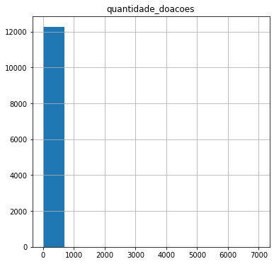

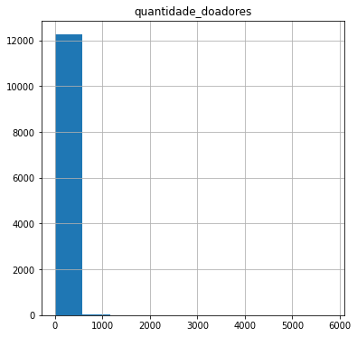

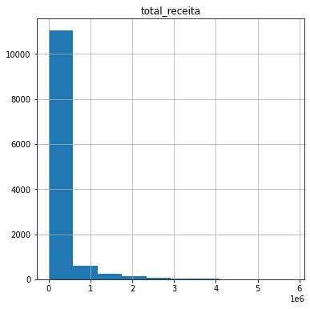

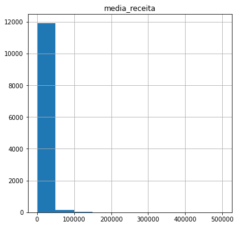

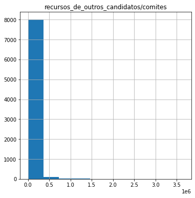

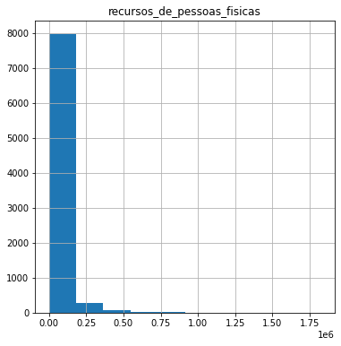

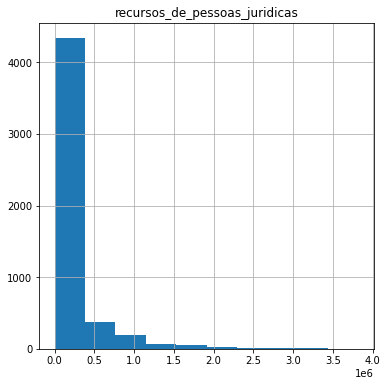

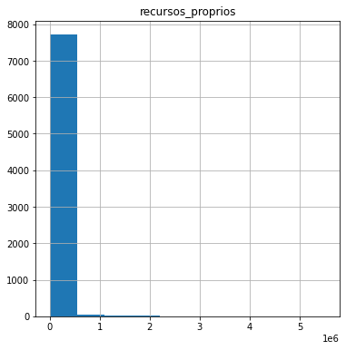

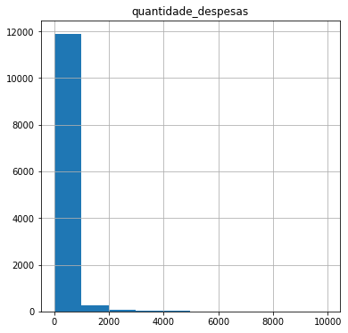

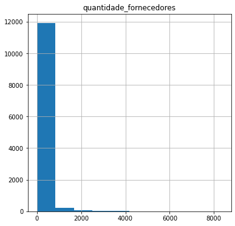

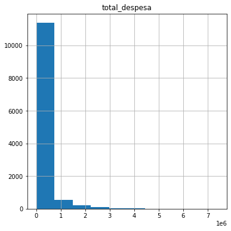

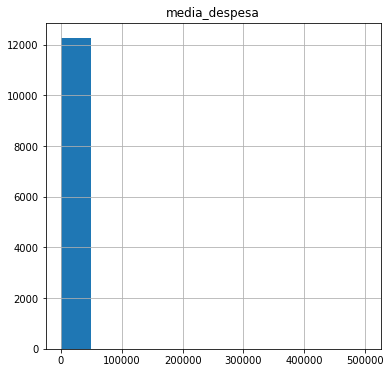

[1 more figures not shown]

```python
def plot_var_dist(dataframe):
  df_numeric = dataframe.select_dtypes(exclude=['object'])
  for col in df_numeric.columns:
    df_numeric.hist(column=[col])

# Vou remover as colunas ano e sequencial_candidato pois elas são categóricas
plot_var_dist(data.drop(columns=['ano', 'sequencial_candidato']))
```

# Pré-Processamento (tratamento dos dados)

## Removendo colunas desnecessárias e simplificando a coluna 'ocupacao'

```python
simple_data = data.drop(columns=['nome', 'sequencial_candidato', 'cargo'])
```

```python
for ocp in data['ocupacao'].unique():
  query_result = data[data.ocupacao == ocp]
  print(ocp, ": {} registros".format(len(query_result)))
  print()
```

```
VEREADOR : 581 registros

SERVIDOR PÚBLICO ESTADUAL : 422 registros

PEDAGOGO : 53 registros

MILITAR REFORMADO : 101 registros

DEPUTADO : 1047 registros

SERVIDOR PÚBLICO FEDERAL : 341 registros

MÉDICO : 487 registros

FEIRANTE, AMBULANTE E MASCATE : 4 registros

GERENTE : 48 registros

OUTROS : 1470 registros

APOSENTADO (EXCETO SERVIDOR PÚBLICO) : 266 registros

COMERCIANTE : 504 registros

VIGILANTE : 34 registros

ADVOGADO : 1048 registros

PROFESSOR DE ENSINO SUPERIOR : 233 registros

FISCAL : 24 registros

ADMINISTRADOR : 281 registros

ASSISTENTE SOCIAL : 38 registros

ODONTÓLOGO : 64 registros

JORNALISTA E REDATOR : 119 registros

```

[output cut: 328 more lines]

```
ESTOFADOR : 1 registros

TÉCNICO DE QUÍMICA : 1 registros

MINISTRO DE ESTADO : 1 registros

BOMBEIRO CIVIL : 2 registros

OCEANÓGRAFO : 1 registros

GEOFÍSICO : 1 registros

AGENTE DE SERVIÇOS FUNERÁRIOS E EMBALSAMADOR : 2 registros

BACTERIOLOGISTA E ASSEMELHADOS : 1 registros
```

```python
for ocp in data['ocupacao'].unique():
  query_result = data[data.ocupacao == ocp]
  count = len(query_result)
  if(count > 400):
    print(ocp, ": {} registros".format(count))
    print()
```

```
VEREADOR : 581 registros

SERVIDOR PÚBLICO ESTADUAL : 422 registros

DEPUTADO : 1047 registros

MÉDICO : 487 registros

OUTROS : 1470 registros

COMERCIANTE : 504 registros

ADVOGADO : 1048 registros

EMPRESÁRIO : 1079 registros
```

Os números mais expressivos são de VEREADOR, DEPUTADO, MÉDICO, COMERCIANTE, ADVOGADO e EMPRESÁRIO.

```python
def converte_ocupacao(dataframe):
  converted = []
  for val in dataframe['ocupacao']:
    if(val == 'VEREADOR'):
      converted.append('VEREADOR')
    elif(val == 'DEPUTADO'):
      converted.append('DEPUTADO')
    elif(val == 'MÉDICO'):
      converted.append('MÉDICO')
    elif(val == 'COMERCIANTE'):
      converted.append('COMERCIANTE')
    elif(val == 'ADVOGADO'):
      converted.append('ADVOGADO')
    elif(val == 'EMPRESÁRIO'):
      converted.append('EMPRESÁRIO')
    else:
      converted.append('OUTRO')

  dataframe['ocupacao'] = converted
  return dataframe

simple_data = converte_ocupacao(simple_data)
simple_data.ocupacao
```

```
0       VEREADOR
1          OUTRO
2          OUTRO
3          OUTRO
4       DEPUTADO
          ...
4931       OUTRO
4932       OUTRO
4933       OUTRO
4934       OUTRO
4935       OUTRO
Name: ocupacao, Length: 12266, dtype: object
```

## Corrigindo variáveis enviesadas

```
array([[<matplotlib.axes._subplots.AxesSubplot object at 0x7fc9286f86d0>,
      dtype=object)
```

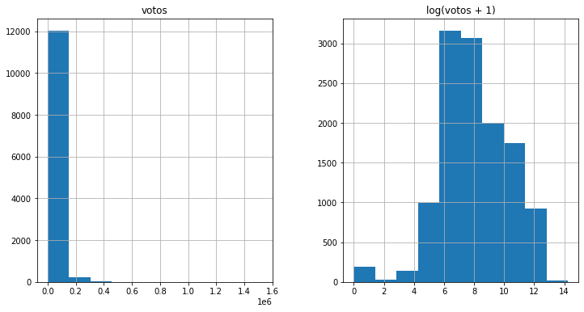

```python
#Variável alvo
matplotlib.rcParams['figure.figsize'] = (12.0, 6.0)
votos = pd.DataFrame({"votos":simple_data["votos"], "log(votos + 1)":np.log1p(simple_data["votos"])})
votos.hist()
```

```python
#log transform the target:
simple_data["votos"] = np.log1p(simple_data["votos"])

#log transform skewed numeric features:
numeric_feats = simple_data.dtypes[simple_data.dtypes != "object"].index

skewed_feats = simple_data[numeric_feats].apply(lambda x: skew(x.dropna())) #compute skewness
skewed_feats = skewed_feats[skewed_feats > 0.75]
skewed_feats = skewed_feats.index

simple_data[skewed_feats] = np.log1p(simple_data[skewed_feats])
simple_data.head()
```

|  | ano | uf | partido | quantidade_doacoes | quantidade_doadores | total_receita | media_receita | recursos_de_outros_candidatos/comites | recursos_de_pessoas_fisicas | recursos_de_pessoas_juridicas | recursos_proprios | quantidade_despesas | quantidade_fornecedores | total_despesa | media_despesa | sexo | grau | estado_civil | ocupacao | votos |
| --- | --- | --- | --- | --- | --- | --- | --- | --- | --- | --- | --- | --- | --- | --- | --- | --- | --- | --- | --- | --- |
| 0 | 2006 | AP | PT | 1.945910 | 1.945910 | 9.717218 | 7.925760 | NaN | 9.105091 | 8.748464 | 7.170888 | 2.708050 | 2.708050 | 9.716230 | 7.077956 | MASCULINO | ENSINO MÉDIO COMPLETO | CASADO(A) | VEREADOR | 9.057189 |
| 1 | 2006 | RO | PT | 2.639057 | 2.639057 | 10.035699 | 7.471276 | 8.798757 | 9.615872 | 6.908755 | 5.308268 | 3.218876 | 3.178054 | 9.919705 | 6.785292 | FEMININO | SUPERIOR COMPLETO | SOLTEIRO(A) | OUTRO | 7.922261 |
| 2 | 2006 | AP | PT | 2.890372 | 2.833213 | 11.905790 | 9.133303 | 7.719130 | 10.438547 | 11.038461 | 10.993748 | 4.820282 | 4.691348 | 11.891449 | 7.210050 | FEMININO | SUPERIOR COMPLETO | VIÚVO(A) | OUTRO | 9.765891 |
| 3 | 2006 | MS | PRONA | 1.945910 | 1.945910 | 8.007074 | 6.216979 | NaN | 7.048386 | 7.004991 | 6.621406 | 2.197225 | 2.197225 | 8.007074 | 5.929961 | MASCULINO | ENSINO MÉDIO INCOMPLETO | CASADO(A) | OUTRO | 7.085064 |
| 4 | 2006 | RO | PT | 3.891820 | 3.891820 | NaN | NaN | NaN | 10.837206 | NaN | 11.141035 | 4.897840 | 4.795791 | 11.664939 | 6.878469 | MASCULINO | ENSINO FUNDAMENTAL COMPLETO | CASADO(A) | DEPUTADO | 10.288818 |

## Lidando com variáveis categóricas

```python
#7037 colunas
simple_data = pd.get_dummies(simple_data)
simple_data.head()
```

|  | ano | quantidade_doacoes | quantidade_doadores | total_receita | media_receita | recursos_de_outros_candidatos/comites | recursos_de_pessoas_fisicas | recursos_de_pessoas_juridicas | recursos_proprios | quantidade_despesas | ... | estado_civil_SEPARADO(A) JUDICIALMENTE | estado_civil_SOLTEIRO(A) | estado_civil_VIÚVO(A) | ocupacao_ADVOGADO | ocupacao_COMERCIANTE | ocupacao_DEPUTADO | ocupacao_EMPRESÁRIO | ocupacao_MÉDICO | ocupacao_OUTRO | ocupacao_VEREADOR |
| --- | --- | --- | --- | --- | --- | --- | --- | --- | --- | --- | --- | --- | --- | --- | --- | --- | --- | --- | --- | --- | --- |
| 0 | 2006 | 1.945910 | 1.945910 | 9.717218 | 7.925760 | NaN | 9.105091 | 8.748464 | 7.170888 | 2.708050 | ... | 0 | 0 | 0 | 0 | 0 | 0 | 0 | 0 | 0 | 1 |
| 1 | 2006 | 2.639057 | 2.639057 | 10.035699 | 7.471276 | 8.798757 | 9.615872 | 6.908755 | 5.308268 | 3.218876 | ... | 0 | 1 | 0 | 0 | 0 | 0 | 0 | 0 | 1 | 0 |
| 2 | 2006 | 2.890372 | 2.833213 | 11.905790 | 9.133303 | 7.719130 | 10.438547 | 11.038461 | 10.993748 | 4.820282 | ... | 0 | 0 | 1 | 0 | 0 | 0 | 0 | 0 | 1 | 0 |
| 3 | 2006 | 1.945910 | 1.945910 | 8.007074 | 6.216979 | NaN | 7.048386 | 7.004991 | 6.621406 | 2.197225 | ... | 0 | 0 | 0 | 0 | 0 | 0 | 0 | 0 | 1 | 0 |
| 4 | 2006 | 3.891820 | 3.891820 | NaN | NaN | NaN | 10.837206 | NaN | 11.141035 | 4.897840 | ... | 0 | 0 | 0 | 0 | 0 | 1 | 0 | 0 | 0 | 0 |

5 rows × 98 columns

## Preenchendo os valores ausentes com a média dos valores da coluna

```python
simple_data = simple_data.fillna(simple_data.mean())
simple_data.head()
```

|  | ano | quantidade_doacoes | quantidade_doadores | total_receita | media_receita | recursos_de_outros_candidatos/comites | recursos_de_pessoas_fisicas | recursos_de_pessoas_juridicas | recursos_proprios | quantidade_despesas | ... | estado_civil_SEPARADO(A) JUDICIALMENTE | estado_civil_SOLTEIRO(A) | estado_civil_VIÚVO(A) | ocupacao_ADVOGADO | ocupacao_COMERCIANTE | ocupacao_DEPUTADO | ocupacao_EMPRESÁRIO | ocupacao_MÉDICO | ocupacao_OUTRO | ocupacao_VEREADOR |
| --- | --- | --- | --- | --- | --- | --- | --- | --- | --- | --- | --- | --- | --- | --- | --- | --- | --- | --- | --- | --- | --- |
| 0 | 2006 | 1.945910 | 1.945910 | 9.717218 | 7.925760 | 8.370968 | 9.105091 | 8.748464 | 7.170888 | 2.708050 | ... | 0 | 0 | 0 | 0 | 0 | 0 | 0 | 0 | 0 | 1 |
| 1 | 2006 | 2.639057 | 2.639057 | 10.035699 | 7.471276 | 8.798757 | 9.615872 | 6.908755 | 5.308268 | 3.218876 | ... | 0 | 1 | 0 | 0 | 0 | 0 | 0 | 0 | 1 | 0 |
| 2 | 2006 | 2.890372 | 2.833213 | 11.905790 | 9.133303 | 7.719130 | 10.438547 | 11.038461 | 10.993748 | 4.820282 | ... | 0 | 0 | 1 | 0 | 0 | 0 | 0 | 0 | 1 | 0 |
| 3 | 2006 | 1.945910 | 1.945910 | 8.007074 | 6.216979 | 8.370968 | 7.048386 | 7.004991 | 6.621406 | 2.197225 | ... | 0 | 0 | 0 | 0 | 0 | 0 | 0 | 0 | 1 | 0 |
| 4 | 2006 | 3.891820 | 3.891820 | 9.670482 | 7.468538 | 8.370968 | 10.837206 | 10.021113 | 11.141035 | 4.897840 | ... | 0 | 0 | 0 | 0 | 0 | 1 | 0 | 0 | 0 | 0 |

5 rows × 98 columns

## Dividindo dados por ano

```python
data_2006 = simple_data[simple_data['ano'] == 2006]
data_2006.head()
```

|  | ano | quantidade_doacoes | quantidade_doadores | total_receita | media_receita | recursos_de_outros_candidatos/comites | recursos_de_pessoas_fisicas | recursos_de_pessoas_juridicas | recursos_proprios | quantidade_despesas | ... | estado_civil_SEPARADO(A) JUDICIALMENTE | estado_civil_SOLTEIRO(A) | estado_civil_VIÚVO(A) | ocupacao_ADVOGADO | ocupacao_COMERCIANTE | ocupacao_DEPUTADO | ocupacao_EMPRESÁRIO | ocupacao_MÉDICO | ocupacao_OUTRO | ocupacao_VEREADOR |
| --- | --- | --- | --- | --- | --- | --- | --- | --- | --- | --- | --- | --- | --- | --- | --- | --- | --- | --- | --- | --- | --- |
| 0 | 2006 | 1.945910 | 1.945910 | 9.717218 | 7.925760 | 8.370968 | 9.105091 | 8.748464 | 7.170888 | 2.708050 | ... | 0 | 0 | 0 | 0 | 0 | 0 | 0 | 0 | 0 | 1 |
| 1 | 2006 | 2.639057 | 2.639057 | 10.035699 | 7.471276 | 8.798757 | 9.615872 | 6.908755 | 5.308268 | 3.218876 | ... | 0 | 1 | 0 | 0 | 0 | 0 | 0 | 0 | 1 | 0 |
| 2 | 2006 | 2.890372 | 2.833213 | 11.905790 | 9.133303 | 7.719130 | 10.438547 | 11.038461 | 10.993748 | 4.820282 | ... | 0 | 0 | 1 | 0 | 0 | 0 | 0 | 0 | 1 | 0 |
| 3 | 2006 | 1.945910 | 1.945910 | 8.007074 | 6.216979 | 8.370968 | 7.048386 | 7.004991 | 6.621406 | 2.197225 | ... | 0 | 0 | 0 | 0 | 0 | 0 | 0 | 0 | 1 | 0 |
| 4 | 2006 | 3.891820 | 3.891820 | 9.670482 | 7.468538 | 8.370968 | 10.837206 | 10.021113 | 11.141035 | 4.897840 | ... | 0 | 0 | 0 | 0 | 0 | 1 | 0 | 0 | 0 | 0 |

5 rows × 98 columns

```python
data_2010 = simple_data[simple_data['ano'] == 2010]
data_2010.head()
```

|  | ano | quantidade_doacoes | quantidade_doadores | total_receita | media_receita | recursos_de_outros_candidatos/comites | recursos_de_pessoas_fisicas | recursos_de_pessoas_juridicas | recursos_proprios | quantidade_despesas | ... | estado_civil_SEPARADO(A) JUDICIALMENTE | estado_civil_SOLTEIRO(A) | estado_civil_VIÚVO(A) | ocupacao_ADVOGADO | ocupacao_COMERCIANTE | ocupacao_DEPUTADO | ocupacao_EMPRESÁRIO | ocupacao_MÉDICO | ocupacao_OUTRO | ocupacao_VEREADOR |
| --- | --- | --- | --- | --- | --- | --- | --- | --- | --- | --- | --- | --- | --- | --- | --- | --- | --- | --- | --- | --- | --- |
| 3388 | 2010 | 3.610918 | 3.583519 | 12.916305 | 9.361041 | 12.503138 | 10.975944 | 8.926358 | 11.463068 | 4.007333 | ... | 0 | 0 | 0 | 0 | 0 | 0 | 1 | 0 | 0 | 0 |
| 3389 | 2010 | 1.386294 | 1.386294 | 8.852379 | 7.754053 | 8.370968 | 8.824994 | 8.610866 | 7.313887 | 1.386294 | ... | 0 | 0 | 0 | 0 | 0 | 0 | 0 | 0 | 1 | 0 |
| 3390 | 2010 | 1.386294 | 1.386294 | 7.518064 | 6.420538 | 5.673323 | 7.313887 | 10.021113 | 3.931826 | 1.386294 | ... | 0 | 0 | 0 | 0 | 0 | 0 | 0 | 0 | 1 | 0 |
| 3391 | 2010 | 0.693147 | 0.693147 | 6.089045 | 6.089045 | 6.089045 | 8.824994 | 10.021113 | 8.458250 | 0.693147 | ... | 0 | 0 | 0 | 0 | 0 | 0 | 0 | 0 | 1 | 0 |
| 3392 | 2010 | 2.772589 | 2.639057 | 12.394629 | 9.829729 | 8.370968 | 8.716208 | 11.100451 | 9.296610 | 4.430817 | ... | 0 | 0 | 0 | 0 | 0 | 1 | 0 | 0 | 0 | 0 |

5 rows × 98 columns

```python
data_2014 = simple_data[simple_data['ano'] == 2014]
data_2014.head()
```

|  | ano | quantidade_doacoes | quantidade_doadores | total_receita | media_receita | recursos_de_outros_candidatos/comites | recursos_de_pessoas_fisicas | recursos_de_pessoas_juridicas | recursos_proprios | quantidade_despesas | ... | estado_civil_SEPARADO(A) JUDICIALMENTE | estado_civil_SOLTEIRO(A) | estado_civil_VIÚVO(A) | ocupacao_ADVOGADO | ocupacao_COMERCIANTE | ocupacao_DEPUTADO | ocupacao_EMPRESÁRIO | ocupacao_MÉDICO | ocupacao_OUTRO | ocupacao_VEREADOR |
| --- | --- | --- | --- | --- | --- | --- | --- | --- | --- | --- | --- | --- | --- | --- | --- | --- | --- | --- | --- | --- | --- |
| 0 | 2014 | 1.386294 | 1.386294 | 7.365813 | 6.268465 | 8.370968 | 7.313887 | 10.021113 | 8.458250 | 1.386294 | ... | 0 | 1 | 0 | 0 | 0 | 0 | 0 | 0 | 1 | 0 |
| 1 | 2014 | 1.791759 | 1.791759 | 8.064951 | 6.456770 | 8.370968 | 8.039480 | 10.021113 | 8.458250 | 1.945910 | ... | 0 | 1 | 0 | 0 | 0 | 0 | 0 | 0 | 1 | 0 |
| 2 | 2014 | 3.713572 | 3.663562 | 12.716781 | 9.079305 | 7.562198 | 11.092869 | 11.945818 | 11.652696 | 4.983607 | ... | 0 | 0 | 0 | 0 | 0 | 0 | 0 | 0 | 1 | 0 |
| 3 | 2014 | 3.401197 | 3.401197 | 11.962218 | 8.595101 | 10.574474 | 11.138739 | 9.741027 | 8.826758 | 4.919981 | ... | 0 | 0 | 0 | 0 | 0 | 0 | 0 | 0 | 1 | 0 |
| 4 | 2014 | 5.081404 | 4.990433 | 13.474546 | 8.491143 | 9.210440 | 12.757293 | 12.531776 | 11.264477 | 6.251904 | ... | 0 | 0 | 0 | 1 | 0 | 0 | 0 | 0 | 0 | 0 |

5 rows × 98 columns

# Treinamento: Construindo e tunando modelos de regressão

```python
X_train = data_2006.drop(columns=['votos', 'ano'])
Y_train = data_2006.votos
X_test = data_2010.drop(columns=['votos', 'ano'])
Y_test = data_2010.votos

X_2014 = data_2014.drop(columns=['votos', 'ano'])
Y_2014 = data_2014.votos
```

```python
#função que faz a validação cruzada 5-Fold e calcula o RMSE
def rmse_cv(model, data, real_values):
    rmse= np.sqrt(-cross_val_score(model, data, real_values, scoring="neg_mean_squared_error", cv = 5))
    return(rmse)
```

### Regressão Linear Simples

```python
reg = LinearRegression().fit(X_train, Y_train)
reg.score(X_test, Y_test)
```

```
-2442762507505761.5
```

```python
rmse_cv(reg, X_test, Y_test).mean()
```

```
114101547608.9085
```

## Ridge

```python
model_ridge = Ridge()
```

```python
# alphas = [0.05, 0.1, 0.3, 1, 3, 5, 10, 15, 30, 50, 75]
# alphas = [0.0001, 0.001, 0.01]
# alphas = [0.000001, 0.00001, 0.0001]
# alphas = [0.00000001, 0.0000001, 0.000001]
# alphas = [0.0000000001, 0.000000001, 0.00000001]
# alphas = [0.0000000000000001, 0.000000000000001, 0.00000000000001]
# alphas = [0.000000000000000001, 0.00000000000000001, 0.0000000000000001]
# alphas = [0.00000000000000000001, 0.0000000000000000001, 0.000000000000000001]
# alphas = [0.0000000000000000000001, 0.000000000000000000001, 0.00000000000000000001]
# alphas = [0.000000000000000000000001, 0.00000000000000000000001, 0.0000000000000000000001]
# alphas = [0.00000000000000000000000001, 0.0000000000000000000000001, 0.000000000000000000000001]
# alphas = [0.0000000000000000000000000001, 0.000000000000000000000000001, 0.00000000000000000000000001]
# alphas = [0.00000000000000000000000000001, 0.00000000000000000000000000005, 0.00000000000000000000000000008]
# alphas = np.linspace(1e-15, 1e-10, num=100)
# alphas = np.linspace(1e-20, 1e-15, num=100)
# alphas = np.linspace(1e-25, 1e-20, num=100)
alphas = np.linspace(1e-30, 1e-25, num=100)
cv_ridge = [rmse_cv(Ridge(alpha = alpha), X_train, Y_train).mean() for alpha in alphas]
```

```python
cv_ridge = pd.Series(cv_ridge, index = alphas)

px.line(cv_ridge, labels={'value': 'RMSE', 'index': 'Alpha'}, title='Relação entre RMSE e valor Alpha')
```

[interactive chart not shown]

### Menor valor de RMSE:

```python
cv_ridge.min()
```

```
0.9513954187081645
```

```python
def find_best_alpha(serie):
  min_rmse = serie.min()
  for alpha in serie.index:
    if(serie[alpha] == min_rmse):
      print("O RMSE Mínimo é: {0} e é atingido com o alpha {1}".format(min_rmse, alpha))
      return alpha
```

```python
best_ridge_alpha = find_best_alpha(cv_ridge)
```

```
O RMSE Mínimo é: 0.9513954187081645 e é atingido com o alpha 8.484863636363636e-26
```

```python
best_model_ridge = Ridge(alpha=8.484863636363636e-26)
best_model_ridge.fit(X_train, Y_train)

best_model_ridge.score( X_test, Y_test)
```

```
-6.701234253824509e+20
```

```python
rmse_cv(best_model_ridge, X_test, Y_test).mean()
```

```
223760997323.95712
```

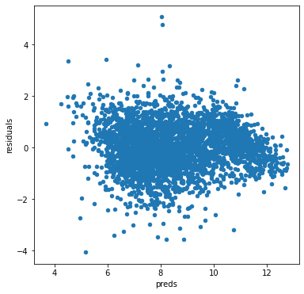

```python
#let's look at the residuals as well:
matplotlib.rcParams['figure.figsize'] = (6.0, 6.0)

preds = pd.DataFrame({"preds":best_model_ridge.predict(X_train), "true":Y_train})
preds["residuals"] = preds["true"] - preds["preds"]
preds.plot(x = "preds", y = "residuals",kind = "scatter")
```

**Os resíduos estão variando numa faixa de -2 a 2, deveriam está bem mais próximos de zero. O modelo não é tão bom.**

## Lasso

```python
alphas = np.linspace(1e-10, 1e-3)

model_lasso = Lasso(max_iter=20000)

cv_lasso = [rmse_cv(Lasso(alpha = alpha), X_train, Y_train).mean() for alpha in alphas]

cv_lasso = pd.Series(cv_lasso, index = alphas)
```

[output not shown]

[output cut: 944 more lines]

[output not shown]

```python
px.line(cv_lasso, labels={'value': 'RMSE', 'index': 'Alpha'}, title='Relação entre RMSE e valor Alpha')
```

[interactive chart not shown]

```python
cv_lasso.min()
```

```
0.948313417843241
```

```python
best_lasso_alpha = find_best_alpha(cv_lasso)
```

```
O RMSE Mínimo é: 0.948313417843241 e é atingido com o alpha 0.000693877581632653
```

```python
best_model_lasso = Lasso(alpha=0.000693877581632653, max_iter=20000)
best_model_lasso.fit(X_train, Y_train)

best_model_lasso.score( X_test, Y_test)
```

```
0.7119016388052551
```

```python
rmse_cv(best_model_lasso, X_test, Y_test).mean()
```

```
1.0272588916975178
```

### Descobrindo a ordem de importância dos coeficientes

```
Lasso picked 74 variables and eliminated the other 22 variables
```

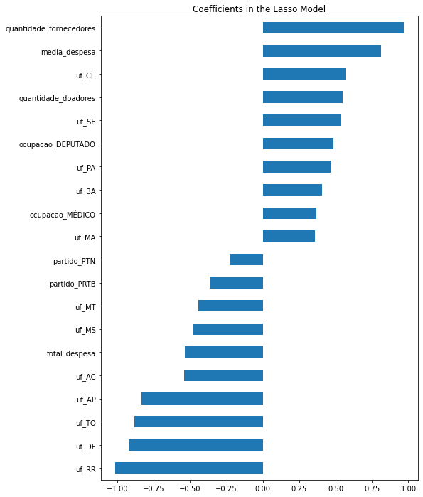

```python
coef = pd.Series(best_model_lasso.coef_, index = X_train.columns)

print("Lasso picked " + str(sum(coef != 0)) + " variables and eliminated the other " +  str(sum(coef == 0)) + " variables")

imp_coef = pd.concat([coef.sort_values().head(10),
                     coef.sort_values().tail(10)])

matplotlib.rcParams['figure.figsize'] = (8.0, 12.0)
imp_coef.plot(kind = "barh")
plt.title("Coefficients in the Lasso Model")
```

### Resíduos

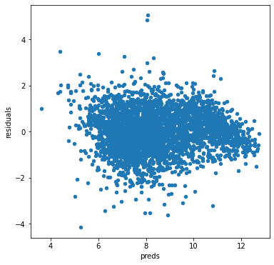

```python
#let's look at the residuals as well:
matplotlib.rcParams['figure.figsize'] = (6.0, 6.0)

preds = pd.DataFrame({"preds":best_model_lasso.predict(X_train), "true":Y_train})
preds["residuals"] = preds["true"] - preds["preds"]
preds.plot(x = "preds", y = "residuals",kind = "scatter")
```

**Os resíduos estão variando numa faixa de -2 a 2, deveriam está bem mais próximos de zero. O modelo não é tão bom.**

### Decision Tree Regressor

```python
dtreg = DecisionTreeRegressor(random_state = 100)
dtreg.fit(X_train, Y_train)

dtreg.score(X_test, Y_test)
```

```
0.5399315929002064
```

```python
rmse_cv(dtreg, X_test, Y_test).mean()
```

```
1.3128681196520844
```

### Resíduos

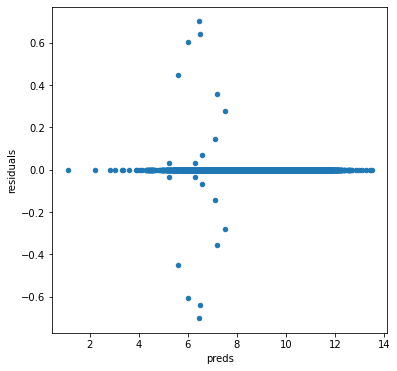

```python
#let's look at the residuals as well:
matplotlib.rcParams['figure.figsize'] = (6.0, 6.0)

preds = pd.DataFrame({"preds":dtreg.predict(X_train), "true":Y_train})
preds["residuals"] = preds["true"] - preds["preds"]
preds.plot(x = "preds", y = "residuals",kind = "scatter")
```

**Os resíduos estão variando numa faixa muito próxima de 0, então o modelo se mostra eficiente, pelo menos para os dados de treino (pode ter ocorrido overfit).**

### **Entre os modelos de regressão Ridge, Lasso e Decision Tree, o modelo Lasso se mostrou mais eficiente.**

# Testes com os dados de 2014

### Juntando dados de 2006 e 2010

```python
data_2006_2010 = pd.concat([data_2006, data_2010])

X2_train = data_2006_2010.drop(columns=['votos', 'ano'])
Y2_train = data_2006_2010.votos

X2_test = data_2014.drop(columns=['votos', 'ano'])
Y2_test = data_2014.votos
```

## Ridge

```python
model_ridge = Ridge(alpha=8.484863636363636e-26)
model_ridge.fit(X2_train, Y2_train)

model_ridge.score( X2_test, Y2_test)
```

```
-1.577139666126608e+20
```

```python
rmse_cv(model_ridge, X2_test, Y2_test).mean()
```

```
155078811546.29126
```

### Resíduos

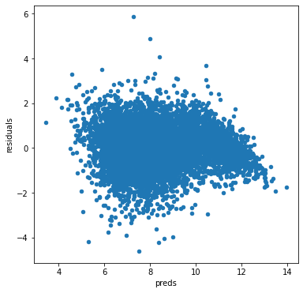

```python
#let's look at the residuals as well:
matplotlib.rcParams['figure.figsize'] = (6.0, 6.0)

preds = pd.DataFrame({"preds":model_ridge.predict(X2_train), "true":Y2_train})
preds["residuals"] = preds["true"] - preds["preds"]
preds.plot(x = "preds", y = "residuals",kind = "scatter")
```

```python
223760997323.95712 > 155078811546.29126
```

```
True
```

### Resíduos

**Os resíduos estão variando numa faixa entre -2 e 2 (aproximadamente), o modelo não é tão bom para prever resultados dos dados de treino.**

## Lasso

```python
model_lasso = Lasso(alpha=0.000693877581632653, max_iter=20000)
model_lasso.fit(X2_train, Y2_train)

model_lasso.score( X2_test, Y2_test)
```

```
0.5005141221803024
```

```python
rmse_cv(model_lasso, X2_test, Y2_test).mean()
```

```
1.6955668308351644
```

### Resíduos

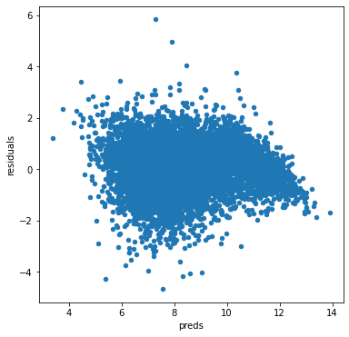

```python
#let's look at the residuals as well:
matplotlib.rcParams['figure.figsize'] = (6.0, 6.0)

preds = pd.DataFrame({"preds":model_lasso.predict(X2_train), "true":Y2_train})
preds["residuals"] = preds["true"] - preds["preds"]
preds.plot(x = "preds", y = "residuals",kind = "scatter")
```

**Os resíduos estão variando numa faixa entre -2 e 2 (aproximadamente), então o modelo não é tão bom para prever resultados de treino.**

## Decision Tree Regressor

```python
dtreg = DecisionTreeRegressor(random_state = 100)
dtreg.fit(X2_train, Y2_train)

dtreg.score(X2_test, Y2_test)
```

```
0.3322324774488459
```

```python
rmse_cv(dtreg, X2_test, Y2_test).mean()
```

```
2.472608093520203
```

### Resíduos

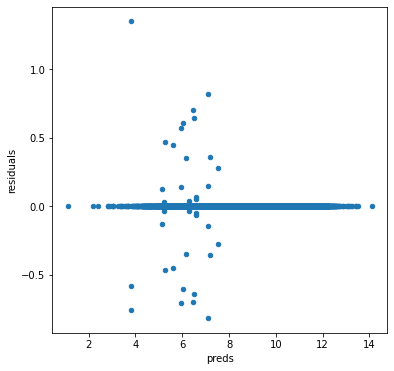

```python
#let's look at the residuals as well:
matplotlib.rcParams['figure.figsize'] = (6.0, 6.0)

preds = pd.DataFrame({"preds":dtreg.predict(X2_train), "true":Y2_train})
preds["residuals"] = preds["true"] - preds["preds"]
preds.plot(x = "preds", y = "residuals",kind = "scatter")
```

**Resíduos muito próximos de 0. Modelo se adequa bem para prever resultados, ao menos para dados de treino.**

## Redescobrindo alphas para o Ridge e Lasso

```python
model_ridge = Ridge()
alphas = [3.031272727272727e-27, 0.0001, 0.001, 0.01, 0.05, 0.1, 0.3, 1, 3, 5, 10, 15, 30, 50, 75]
cv_ridge = [rmse_cv(Ridge(alpha = alpha), X2_train, Y2_train).mean() for alpha in alphas]
```

```python
cv_ridge = pd.Series(cv_ridge, index = alphas)

px.line(cv_ridge, labels={'value': 'RMSE', 'index': 'Alpha'}, title='Relação entre RMSE e valor Alpha')
```

[interactive chart not shown]

```python
cv_ridge.min()
```

```
1.0174989408915363
```

```python
best_ridge_alpha = find_best_alpha(cv_ridge)
```

```
O RMSE Mínimo é: 1.0174989408915363 e é atingido com o alpha 30.0
```

```python
best_model_ridge = Ridge(alpha=30)
best_model_ridge.fit(X2_train, Y2_train)

best_model_ridge.score( X2_test, Y2_test)
```

```
0.5001358154190123
```

```python
rmse_cv(best_model_ridge, X2_test, Y2_test).mean()
```

```
1.691871175151654
```

### Resíduos

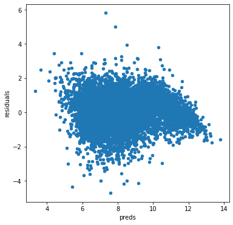

```python
#let's look at the residuals as well:
matplotlib.rcParams['figure.figsize'] = (6.0, 6.0)

preds = pd.DataFrame({"preds":best_model_ridge.predict(X2_train), "true":Y2_train})
preds["residuals"] = preds["true"] - preds["preds"]
preds.plot(x = "preds", y = "residuals",kind = "scatter")
```

**Treinar o modelo com os dados de 2006 e testar com os de 2010 para achar um alpha não se mostrou uma abordagem eficiente para a regressão ridge. Conseguimos achar um alpha muito melhor ao tunelar com os dados de treino agrupados (2006 e 2010)**

## Lasso

```python
# alphas = [3.031272727272727e-27, 0.0001, 0.001, 0.01, 0.05, 0.1, 0.3, 1, 3, 5, 10, 15, 30, 50, 75]
alphas = np.linspace(1e-10, 0.01)

model_lasso = Lasso(max_iter=20000)

cv_lasso = [rmse_cv(Lasso(alpha = alpha), X2_train, Y2_train).mean() for alpha in alphas]

cv_lasso = pd.Series(cv_lasso, index = alphas)
```

[output not shown]

[output cut: 228 more lines]

[output not shown]

```python
px.line(cv_lasso, labels={'value': 'RMSE', 'index': 'Alpha'}, title='Relação entre RMSE e valor Alpha')
```

[interactive chart not shown]

```python
cv_lasso.min()
```

```
1.018983149094273
```

```python
best_lasso_alpha = find_best_alpha(cv_lasso)
```

```
O RMSE Mínimo é: 1.018983149094273 e é atingido com o alpha 0.0012244898836734695
```

```python
best_model_lasso = Lasso(alpha=0.001, max_iter=20000)
best_model_lasso.fit(X2_train, Y2_train)

best_model_lasso.score( X2_test, Y2_test)
```

```
0.5002337815607429
```

```python
rmse_cv(best_model_lasso, X2_test, Y2_test).mean()
```

```
1.6948275492477702
```

### Resíduos

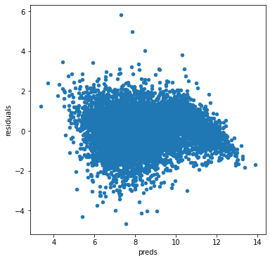

```python
#let's look at the residuals as well:
matplotlib.rcParams['figure.figsize'] = (6.0, 6.0)

preds = pd.DataFrame({"preds":best_model_lasso.predict(X2_train), "true":Y2_train})
preds["residuals"] = preds["true"] - preds["preds"]
preds.plot(x = "preds", y = "residuals",kind = "scatter")
```

**Para a regressão Lasso, descobrir um alpha com os dados de 2006 como treino e 2010 como teste, realmente funcionou. O Alpha descoberto trás resultados similares ao alpha descoberto ao juntar as bases de 2006 e 2010 e testando em 2014. Entretanto, o modelo ainda não é muito bom para prever resultados.**